# 001170_ReimerLab_public_demo_001170_demo_ipynb

## Installing requirements

The cell below installs every Python package needed to run this notebook, at fully pinned versions, using [`uv`](https://github.com/astral-sh/uv) for fast resolution. In Colab the cell is collapsed by default — click the ▶ button to run it.

```python
# install cell skipped during CI (deps preinstalled into system Python)
```

> **⚠️ Restart runtime after install**

> The install may upgrade packages already loaded in the kernel. Go to **Runtime → Restart session**, then **Run all cells below** (skip this install cell on re-run).

# Tutorial for Mesoscale Two-Photon Calcium Imaging of Population Level Odor Responses from the Mouse Olfactory Bulb.

This tutorial shows how to access the data related to [DANDI:001170](https://dandiarchive.org/dandiset/001170/draft) using `pynwb`.

This dataset contains the 2-photon calcium imaging, treadmill position and velocity traces and odor stimulus events, along with subject and session metadata.

Contents:

- Streaming an NWB file
- Reading an NWB file
- Access Subject and Session metadata
- Access Raw Imaging
- Access Processed Imaging
- Access Odor Stimuli
- Access Treadmill traces

# Select the subject and session you want to load

```python
subject_id = 134
session_id = 22
nwbfile_path = f"sub-{subject_id}/sub-{subject_id}_ses-{session_id}_behavior+ophys.nwb"
```

# Streaming an NWB file

This section demonstrates how to access the files on the [DANDI Archive](https://dandiarchive.org) without downloading them. Based on the [Streaming NWB files](https://pynwb.readthedocs.io/en/stable/tutorials/advanced_io/streaming.html) tutorial from [PyNWB](https://pynwb.readthedocs.io/en/stable/#).

The `dandi.dandiapi.DandiAPIClient` can be used to get the S3 URL of the NWB file stored in the DANDI Archive.

```python
from dandi.dandiapi import DandiAPIClient

dandiset_id = "001170"

with DandiAPIClient() as client:
    asset = client.get_dandiset(dandiset_id, 'draft').get_asset_by_path(nwbfile_path)
    s3_url = asset.get_content_url(follow_redirects=1, strip_query=False)
```

We will use `remfile` for streaming the file. You can read more about `remfile` at [this tutorial section](https://pynwb.readthedocs.io/en/stable/tutorials/advanced_io/streaming.html#method-3-remfile).

```python
import h5py
import remfile

# The disk cache keeps blocks that have already been fetched, so repeated
# reads of the same part of the file do not go back over the network.
file = remfile.File(s3_url, disk_cache=remfile.DiskCache("nwb-cache"))
h5_file = h5py.File(file, "r")
```

# Reading an NWB file

This section demonstrates how to read an NWB file using `pynwb`.

Based on the [NWB File Basics](https://pynwb.readthedocs.io/en/stable/tutorials/general/plot_file.html#sphx-glr-tutorials-general-plot-file-py) tutorial from [PyNWB](https://pynwb.readthedocs.io/en/stable/#).

An NWBFile represents a single session of an experiment. Each NWBFile must have a `session description`, `identifier`, and `session start time`.

Reading is carried out using the NWBHDF5IO class. To read the NWB file use the read mode ("r") to retrieve an NWBFile object.

```python
from pynwb import NWBHDF5IO
io = NWBHDF5IO(file=h5_file, load_namespaces=True)
nwbfile = io.read()
nwbfile
```

root (NWBFile)

session_description: In this study, we explore odor-evoked activity representation in the olfactory bulb (OB) and how odor responses enable odor discrimination. Contrary to some previously cited theories that suggest a sparse representation, we hypothesize a more dense representation during odor presentation. A key question is how odors are reliably encoded in OB activity patterns, and how these patterns contribute to early odor processing. To address this problem, we recorded population level odor responses from the mouse OB with mesoscale two photon calcium imaging and applied machine learning techniques to suggest a model in which sparse coding is largely sufficient for olfaction, but redundant information may make odor coding more robust across different variables.

identifier: ed03639d-3530-41f0-ab25-a0c31631a85a

**session_start_time**

2022-07-21 00:00:00-05:00

**timestamps_reference_time**

2022-07-21 00:00:00-05:00

**file_create_date**

**0**

2024-08-07 00:21:45.469158+02:00

**experimenter**

('Pirhayatifard, Delaram', 'Hanson, Elizabeth', 'Pfaffinger, Paul', 'Arenkiel, Benjamin', 'Reimer, Jacob')

**related_publications**

('https://doi.org/10.1101/2023.04.24.538157', 'https://icml-compbio.github.io/2023/papers/WCBICML2023_paper122.pdf')

**acquisition**

**treadmill_position (SpatialSeries)**

resolution: -1.0

comments: no comments

description: treadmill position from Treadmill table

conversion: 1.0

offset: 0.0

unit: meters

**data**

HDF5 dataset

| Data type | float64 |
| --- | --- |
| Shape | (1044900,) |
| Array size | 7.97 MiB |
| Chunk shape | (1044900,) |
| Compression | gzip |
| Compression opts | 4 |
| Uncompressed size (bytes) | 8359200 |
| Compressed size (bytes) | 449850 |
| Compression ratio | 18.58219406468823 |

**timestamps**

HDF5 dataset

| Data type | float64 |
| --- | --- |
| Shape | (1044900,) |
| Array size | 7.97 MiB |
| Chunk shape | (1044900,) |
| Compression | gzip |
| Compression opts | 4 |
| Uncompressed size (bytes) | 8359200 |
| Compressed size (bytes) | 6151141 |
| Compression ratio | 1.3589673850753867 |

timestamps_unit: seconds

interval: 1

reference_frame: unknown

**timestamp_link**

0: processing/behavior/treadmill_velocity/timestamps

**two_photon_series_FOV1_channel1 (TwoPhotonSeries)**

resolution: -1.0

comments: no comments

description: FOV1 refers to the left part of the original ScanImage acquisition. To maximize frame rates in each imaging session, fields of view were defined for acquisition that included a single plane visualizing only the dorsal surface of bilateral OBs (1800 um long x ~600um wide fields of view that were tiled to cover a total field of view that was 1800-2500 um wide). Images were acquired continuously throughout experiments (during odor presentations, intertrial, and inter-block intervals), with 5um/pixel resolution at the fastest possible frame rate allowed by the imaging parameters (15-18 Hz).

conversion: 1.0

offset: 0.0

unit: n.a.

**data**

HDF5 dataset

| Data type | int16 |
| --- | --- |
| Shape | (91000, 120, 433) |
| Array size | 8.81 GiB |
| Chunk shape | (96, 120, 433) |
| Compression | gzip |
| Compression opts | 4 |
| Uncompressed size (bytes) | 9456720000 |
| Compressed size (bytes) | 5400460181 |
| Compression ratio | 1.7510952183798723 |

**timestamps**

HDF5 dataset

| Data type | float64 |
| --- | --- |
| Shape | (91000,) |
| Array size | 710.94 KiB |
| Chunk shape | (91000,) |
| Compression | gzip |
| Compression opts | 4 |
| Uncompressed size (bytes) | 728000 |
| Compressed size (bytes) | 556451 |
| Compression ratio | 1.3082912960889639 |

timestamps_unit: seconds

interval: 1

**dimension**

HDF5 dataset

| Data type | int32 |
| --- | --- |
| Shape | (2,) |
| Array size | 8.00 bytes |
| Chunk shape | None |
| Compression | None |
| Compression opts | None |
| Uncompressed size (bytes) | 8 |
| Compressed size (bytes) | 8 |
| Compression ratio | 1.0 |

[433 120]

**imaging_plane (ImagingPlane)**

**optical_channel**

**0 (OpticalChannel)**

description: Green emitted light was collected through a 525/50 filter and a gallium arsenide phosphide photomultiplier tube (Hamamatsu).

emission_lambda: 525.0

description: Imaging plane for the Green channel recorded with 2p microscope.

**device (Device)**

description: Janelia 2P-RAM mesoscope.

manufacturer: ThorLabs

excitation_lambda: 920.0

indicator: GCaMP6f

location: OB

conversion: 1.0

unit: meters

origin_coords_unit: meters

grid_spacing_unit: meters

**two_photon_series_FOV2_channel1 (TwoPhotonSeries)**

resolution: -1.0

comments: no comments

description: FOV2 refers to the central part of the original ScanImage acquisition. To maximize frame rates in each imaging session, fields of view were defined for acquisition that included a single plane visualizing only the dorsal surface of bilateral OBs (1800 um long x ~600um wide fields of view that were tiled to cover a total field of view that was 1800-2500 um wide). Images were acquired continuously throughout experiments (during odor presentations, intertrial, and inter-block intervals), with 5um/pixel resolution at the fastest possible frame rate allowed by the imaging parameters (15-18 Hz).

conversion: 1.0

offset: 0.0

unit: n.a.

**data**

HDF5 dataset

| Data type | int16 |
| --- | --- |
| Shape | (91000, 120, 433) |
| Array size | 8.81 GiB |
| Chunk shape | (96, 120, 433) |
| Compression | gzip |
| Compression opts | 4 |
| Uncompressed size (bytes) | 9456720000 |
| Compressed size (bytes) | 6217826983 |
| Compression ratio | 1.520904332953518 |

**timestamps**

HDF5 dataset

| Data type | float64 |
| --- | --- |
| Shape | (91000,) |
| Array size | 710.94 KiB |
| Chunk shape | (91000,) |
| Compression | gzip |
| Compression opts | 4 |
| Uncompressed size (bytes) | 728000 |
| Compressed size (bytes) | 556451 |
| Compression ratio | 1.3082912960889639 |

timestamps_unit: seconds

interval: 1

**dimension**

HDF5 dataset

| Data type | int32 |
| --- | --- |
| Shape | (2,) |
| Array size | 8.00 bytes |
| Chunk shape | None |
| Compression | None |
| Compression opts | None |
| Uncompressed size (bytes) | 8 |
| Compressed size (bytes) | 8 |
| Compression ratio | 1.0 |

[433 120]

**imaging_plane (ImagingPlane)**

**optical_channel**

**0 (OpticalChannel)**

description: Green emitted light was collected through a 525/50 filter and a gallium arsenide phosphide photomultiplier tube (Hamamatsu).

emission_lambda: 525.0

description: Imaging plane for the Green channel recorded with 2p microscope.

**device (Device)**

description: Janelia 2P-RAM mesoscope.

manufacturer: ThorLabs

excitation_lambda: 920.0

indicator: GCaMP6f

location: OB

conversion: 1.0

unit: meters

origin_coords_unit: meters

grid_spacing_unit: meters

**two_photon_series_FOV3_channel1 (TwoPhotonSeries)**

resolution: -1.0

comments: no comments

description: FOV3 refers to the right part of the original ScanImage acquisition. To maximize frame rates in each imaging session, fields of view were defined for acquisition that included a single plane visualizing only the dorsal surface of bilateral OBs (1800 um long x ~600um wide fields of view that were tiled to cover a total field of view that was 1800-2500 um wide). Images were acquired continuously throughout experiments (during odor presentations, intertrial, and inter-block intervals), with 5um/pixel resolution at the fastest possible frame rate allowed by the imaging parameters (15-18 Hz).

conversion: 1.0

offset: 0.0

unit: n.a.

**data**

HDF5 dataset

| Data type | int16 |
| --- | --- |
| Shape | (91000, 120, 433) |
| Array size | 8.81 GiB |
| Chunk shape | (96, 120, 433) |
| Compression | gzip |
| Compression opts | 4 |
| Uncompressed size (bytes) | 9456720000 |
| Compressed size (bytes) | 6494167269 |
| Compression ratio | 1.4561866992773327 |

**timestamps**

HDF5 dataset

| Data type | float64 |
| --- | --- |
| Shape | (91000,) |
| Array size | 710.94 KiB |
| Chunk shape | (91000,) |
| Compression | gzip |
| Compression opts | 4 |
| Uncompressed size (bytes) | 728000 |
| Compressed size (bytes) | 556451 |
| Compression ratio | 1.3082912960889639 |

timestamps_unit: seconds

interval: 1

**dimension**

HDF5 dataset

| Data type | int32 |
| --- | --- |
| Shape | (2,) |
| Array size | 8.00 bytes |
| Chunk shape | None |
| Compression | None |
| Compression opts | None |
| Uncompressed size (bytes) | 8 |
| Compressed size (bytes) | 8 |
| Compression ratio | 1.0 |

[433 120]

**imaging_plane (ImagingPlane)**

**optical_channel**

**0 (OpticalChannel)**

description: Green emitted light was collected through a 525/50 filter and a gallium arsenide phosphide photomultiplier tube (Hamamatsu).

emission_lambda: 525.0

description: Imaging plane for the Green channel recorded with 2p microscope.

**device (Device)**

description: Janelia 2P-RAM mesoscope.

manufacturer: ThorLabs

excitation_lambda: 920.0

indicator: GCaMP6f

location: OB

conversion: 1.0

unit: meters

origin_coords_unit: meters

grid_spacing_unit: meters

**keywords**

HDF5 dataset

| Data type | object |
| --- | --- |
| Shape | (3,) |
| Array size | 24.00 bytes |
| Chunk shape | None |
| Compression | None |
| Compression opts | None |
| Uncompressed size (bytes) | 24 |
| Compressed size (bytes) | 48 |
| Compression ratio | 0.5 |

['odor-evoked activity' 'olfactory bulb' 'two photon calcium imaging']

**processing**

**behavior (ProcessingModule)**

description: behavioral data processing

**treadmill_velocity (TimeSeries)**

resolution: -1.0

comments: no comments

description: treadmill velocity from Treadmill table

conversion: 1.0

offset: 0.0

unit: unknown

**data**

HDF5 dataset

| Data type | float64 |
| --- | --- |
| Shape | (1044900,) |
| Array size | 7.97 MiB |
| Chunk shape | (1044900,) |
| Compression | gzip |
| Compression opts | 4 |
| Uncompressed size (bytes) | 8359200 |
| Compressed size (bytes) | 7209847 |
| Compression ratio | 1.1594143398604715 |

**timestamps (link to acquisition/treadmill_position/timestamps)**

HDF5 dataset

| Data type | float64 |
| --- | --- |
| Shape | (1044900,) |
| Array size | 7.97 MiB |
| Chunk shape | (1044900,) |
| Compression | gzip |
| Compression opts | 4 |
| Uncompressed size (bytes) | 8359200 |
| Compressed size (bytes) | 6151141 |
| Compression ratio | 1.3589673850753867 |

timestamps_unit: seconds

interval: 1

**ophys (ProcessingModule)**

description: ophys data processing

**average_images (Images)**

description: Average image of from SummaryImages.Average table.

**average_image_FOV1_channel1 (GrayscaleImage)**

description: Average image of FOV1 Channel 1.

**average_image_FOV2_channel1 (GrayscaleImage)**

description: Average image of FOV2 Channel 1.

**average_image_FOV3_channel1 (GrayscaleImage)**

description: Average image of FOV3 Channel 1.

**correlation_images (Images)**

description: Correlation image from SummaryImages.Correlation table.

**correlation_image_FOV1_channel1 (GrayscaleImage)**

description: Correlation image of FOV1 Channel 1

**correlation_image_FOV2_channel1 (GrayscaleImage)**

description: Correlation image of FOV2 Channel 1

**correlation_image_FOV3_channel1 (GrayscaleImage)**

description: Correlation image of FOV3 Channel 1

**fluorescence (Fluorescence)**

**fluorescence_FOV1_channel1 (RoiResponseSeries)**

resolution: -1.0

comments: no comments

description: Fluorescence traces from FOV1 Channel1

conversion: 1.0

offset: 0.0

unit: n.a.

**data**

HDF5 dataset

| Data type | float32 |
| --- | --- |
| Shape | (182000, 17) |
| Array size | 11.80 MiB |
| Chunk shape | (160575, 15) |
| Compression | gzip |
| Compression opts | 4 |
| Uncompressed size (bytes) | 12376000 |
| Compressed size (bytes) | 10756953 |
| Compression ratio | 1.15051167370537 |

**timestamps**

HDF5 dataset

| Data type | float64 |
| --- | --- |
| Shape | (182000,) |
| Array size | 1.39 MiB |
| Chunk shape | (182000,) |
| Compression | gzip |
| Compression opts | 4 |
| Uncompressed size (bytes) | 1456000 |
| Compressed size (bytes) | 1101454 |
| Compression ratio | 1.3218890666337404 |

timestamps_unit: seconds

interval: 1

**rois (DynamicTableRegion)**

description: all ROIs

**table (PlaneSegmentation)**

description: Output from segmenting FOV1 Channel 1.

**imaging_plane (ImagingPlane)**

**optical_channel**

**0 (OpticalChannel)**

description: Green emitted light was collected through a 525/50 filter and a gallium arsenide phosphide photomultiplier tube (Hamamatsu).

emission_lambda: 525.0

description: Imaging plane for the Green channel recorded with 2p microscope.

**device (Device)**

description: Janelia 2P-RAM mesoscope.

manufacturer: ThorLabs

excitation_lambda: 920.0

indicator: GCaMP6f

location: OB

conversion: 1.0

unit: meters

origin_coords_unit: meters

grid_spacing_unit: meters

**columns**

**pixel_mask**

Pixel masks for each ROI

**table**

| id | pixel_mask |
| --- | --- |
| 0 | [[150, 83, 1.0], [151, 83, 1.0], [152, 83, 1.0], [153, 83, 1.0], [154, 83, 1.0], [155, 83, 1.0], [156, 83, 1.0], [157, 83, 1.0], [158, 83, 1.0], [159, 83, 1.0], [160, 83, 1.0], [161, 83, 1.0], [149, 8… |
| 1 | [[152, 91, 1.0], [153, 91, 1.0], [154, 91, 1.0], [155, 91, 1.0], [156, 91, 1.0], [150, 92, 1.0], [151, 92, 1.0], [152, 92, 1.0], [153, 92, 1.0], [154, 92, 1.0], [155, 92, 1.0], [156, 92, 1.0], [157, 9… |
| 2 | [[145, 100, 1.0], [146, 100, 1.0], [147, 100, 1.0], [143, 101, 1.0], [144, 101, 1.0], [145, 101, 1.0], [146, 101, 1.0], [147, 101, 1.0], [148, 101, 1.0], [149, 101, 1.0], [142, 102, 1.0], [143, 102, 1… |
| 3 | [[138, 90, 1.0], [139, 90, 1.0], [140, 90, 1.0], [137, 91, 1.0], [138, 91, 1.0], [139, 91, 1.0], [140, 91, 1.0], [141, 91, 1.0], [136, 92, 1.0], [137, 92, 1.0], [138, 92, 1.0], [139, 92, 1.0], [140, 9… |

... and 13 more row(s).

**fluorescence_FOV2_channel1 (RoiResponseSeries)**

resolution: -1.0

comments: no comments

description: Fluorescence traces from FOV2 Channel1

conversion: 1.0

offset: 0.0

unit: n.a.

**data**

HDF5 dataset

| Data type | float32 |
| --- | --- |
| Shape | (182000, 48) |
| Array size | 33.33 MiB |
| Chunk shape | (94775, 25) |
| Compression | gzip |
| Compression opts | 4 |
| Uncompressed size (bytes) | 34944000 |
| Compressed size (bytes) | 30484595 |
| Compression ratio | 1.1462838853525854 |

**timestamps**

HDF5 dataset

| Data type | float64 |
| --- | --- |
| Shape | (182000,) |
| Array size | 1.39 MiB |
| Chunk shape | (182000,) |
| Compression | gzip |
| Compression opts | 4 |
| Uncompressed size (bytes) | 1456000 |
| Compressed size (bytes) | 1101454 |
| Compression ratio | 1.3218890666337404 |

timestamps_unit: seconds

interval: 1

**rois (DynamicTableRegion)**

description: all ROIs

**table (PlaneSegmentation)**

description: Output from segmenting FOV2 Channel 1.

**imaging_plane (ImagingPlane)**

**optical_channel**

**0 (OpticalChannel)**

description: Green emitted light was collected through a 525/50 filter and a gallium arsenide phosphide photomultiplier tube (Hamamatsu).

emission_lambda: 525.0

description: Imaging plane for the Green channel recorded with 2p microscope.

**device (Device)**

description: Janelia 2P-RAM mesoscope.

manufacturer: ThorLabs

excitation_lambda: 920.0

indicator: GCaMP6f

location: OB

conversion: 1.0

unit: meters

origin_coords_unit: meters

grid_spacing_unit: meters

**columns**

**pixel_mask**

Pixel masks for each ROI

**table**

| id | pixel_mask |
| --- | --- |
| 0 | [[159, 51, 1.0], [160, 51, 1.0], [154, 52, 1.0], [155, 52, 1.0], [156, 52, 1.0], [157, 52, 1.0], [158, 52, 1.0], [159, 52, 1.0], [160, 52, 1.0], [161, 52, 1.0], [162, 52, 1.0], [151, 53, 1.0], [152, 5… |
| 1 | [[136, 63, 1.0], [137, 63, 1.0], [138, 63, 1.0], [139, 63, 1.0], [140, 63, 1.0], [141, 63, 1.0], [135, 64, 1.0], [136, 64, 1.0], [137, 64, 1.0], [138, 64, 1.0], [139, 64, 1.0], [140, 64, 1.0], [141, 6… |
| 2 | [[144, 96, 1.0], [145, 96, 1.0], [150, 96, 1.0], [151, 96, 1.0], [142, 97, 1.0], [143, 97, 1.0], [144, 97, 1.0], [145, 97, 1.0], [146, 97, 1.0], [147, 97, 1.0], [148, 97, 1.0], [149, 97, 1.0], [150, 9… |
| 3 | [[146, 85, 1.0], [144, 86, 1.0], [145, 86, 1.0], [146, 86, 1.0], [147, 86, 1.0], [148, 86, 1.0], [149, 86, 1.0], [143, 87, 1.0], [144, 87, 1.0], [145, 87, 1.0], [146, 87, 1.0], [147, 87, 1.0], [148, 8… |

... and 44 more row(s).

**fluorescence_FOV3_channel1 (RoiResponseSeries)**

resolution: -1.0

comments: no comments

description: Fluorescence traces from FOV3 Channel1

conversion: 1.0

offset: 0.0

unit: n.a.

**data**

HDF5 dataset

| Data type | float32 |
| --- | --- |
| Shape | (182000, 8) |
| Array size | 5.55 MiB |
| Chunk shape | (182000, 8) |
| Compression | gzip |
| Compression opts | 4 |
| Uncompressed size (bytes) | 5824000 |
| Compressed size (bytes) | 5051373 |
| Compression ratio | 1.1529538602672975 |

**timestamps**

HDF5 dataset

| Data type | float64 |
| --- | --- |
| Shape | (182000,) |
| Array size | 1.39 MiB |
| Chunk shape | (182000,) |
| Compression | gzip |
| Compression opts | 4 |
| Uncompressed size (bytes) | 1456000 |
| Compressed size (bytes) | 1101454 |
| Compression ratio | 1.3218890666337404 |

timestamps_unit: seconds

interval: 1

**rois (DynamicTableRegion)**

description: all ROIs

**table (PlaneSegmentation)**

description: Output from segmenting FOV3 Channel 1.

**imaging_plane (ImagingPlane)**

**optical_channel**

**0 (OpticalChannel)**

description: Green emitted light was collected through a 525/50 filter and a gallium arsenide phosphide photomultiplier tube (Hamamatsu).

emission_lambda: 525.0

description: Imaging plane for the Green channel recorded with 2p microscope.

**device (Device)**

description: Janelia 2P-RAM mesoscope.

manufacturer: ThorLabs

excitation_lambda: 920.0

indicator: GCaMP6f

location: OB

conversion: 1.0

unit: meters

origin_coords_unit: meters

grid_spacing_unit: meters

**columns**

**pixel_mask**

Pixel masks for each ROI

**table**

| id | pixel_mask |
| --- | --- |
| 0 | [[335, 89, 1.0], [332, 90, 1.0], [333, 90, 1.0], [334, 90, 1.0], [335, 90, 1.0], [336, 90, 1.0], [337, 90, 1.0], [338, 90, 1.0], [339, 90, 1.0], [327, 91, 1.0], [328, 91, 1.0], [329, 91, 1.0], [330, 9… |
| 1 | [[325, 77, 1.0], [326, 77, 1.0], [327, 77, 1.0], [328, 77, 1.0], [329, 77, 1.0], [323, 78, 1.0], [324, 78, 1.0], [325, 78, 1.0], [326, 78, 1.0], [327, 78, 1.0], [328, 78, 1.0], [329, 78, 1.0], [330, 7… |
| 2 | [[351, 92, 1.0], [352, 92, 1.0], [353, 92, 1.0], [354, 92, 1.0], [355, 92, 1.0], [349, 93, 1.0], [350, 93, 1.0], [351, 93, 1.0], [352, 93, 1.0], [353, 93, 1.0], [354, 93, 1.0], [355, 93, 1.0], [356, 9… |
| 3 | [[296, 90, 1.0], [297, 90, 1.0], [293, 91, 1.0], [294, 91, 1.0], [295, 91, 1.0], [296, 91, 1.0], [297, 91, 1.0], [298, 91, 1.0], [299, 91, 1.0], [300, 91, 1.0], [291, 92, 1.0], [292, 92, 1.0], [293, 9… |

... and 4 more row(s).

**image_segmentation (ImageSegmentation)**

**plane_segmentation_FOV1_channel1 (PlaneSegmentation)**

description: Output from segmenting FOV1 Channel 1.

**imaging_plane (ImagingPlane)**

**optical_channel**

**0 (OpticalChannel)**

description: Green emitted light was collected through a 525/50 filter and a gallium arsenide phosphide photomultiplier tube (Hamamatsu).

emission_lambda: 525.0

description: Imaging plane for the Green channel recorded with 2p microscope.

**device (Device)**

description: Janelia 2P-RAM mesoscope.

manufacturer: ThorLabs

excitation_lambda: 920.0

indicator: GCaMP6f

location: OB

conversion: 1.0

unit: meters

origin_coords_unit: meters

grid_spacing_unit: meters

**columns**

**pixel_mask**

Pixel masks for each ROI

**table**

| id | pixel_mask |
| --- | --- |
| 0 | [[150, 83, 1.0], [151, 83, 1.0], [152, 83, 1.0], [153, 83, 1.0], [154, 83, 1.0], [155, 83, 1.0], [156, 83, 1.0], [157, 83, 1.0], [158, 83, 1.0], [159, 83, 1.0], [160, 83, 1.0], [161, 83, 1.0], [149, 8… |
| 1 | [[152, 91, 1.0], [153, 91, 1.0], [154, 91, 1.0], [155, 91, 1.0], [156, 91, 1.0], [150, 92, 1.0], [151, 92, 1.0], [152, 92, 1.0], [153, 92, 1.0], [154, 92, 1.0], [155, 92, 1.0], [156, 92, 1.0], [157, 9… |
| 2 | [[145, 100, 1.0], [146, 100, 1.0], [147, 100, 1.0], [143, 101, 1.0], [144, 101, 1.0], [145, 101, 1.0], [146, 101, 1.0], [147, 101, 1.0], [148, 101, 1.0], [149, 101, 1.0], [142, 102, 1.0], [143, 102, 1… |
| 3 | [[138, 90, 1.0], [139, 90, 1.0], [140, 90, 1.0], [137, 91, 1.0], [138, 91, 1.0], [139, 91, 1.0], [140, 91, 1.0], [141, 91, 1.0], [136, 92, 1.0], [137, 92, 1.0], [138, 92, 1.0], [139, 92, 1.0], [140, 9… |

... and 13 more row(s).

**plane_segmentation_FOV2_channel1 (PlaneSegmentation)**

description: Output from segmenting FOV2 Channel 1.

**imaging_plane (ImagingPlane)**

**optical_channel**

**0 (OpticalChannel)**

description: Green emitted light was collected through a 525/50 filter and a gallium arsenide phosphide photomultiplier tube (Hamamatsu).

emission_lambda: 525.0

description: Imaging plane for the Green channel recorded with 2p microscope.

**device (Device)**

description: Janelia 2P-RAM mesoscope.

manufacturer: ThorLabs

excitation_lambda: 920.0

indicator: GCaMP6f

location: OB

conversion: 1.0

unit: meters

origin_coords_unit: meters

grid_spacing_unit: meters

**columns**

**pixel_mask**

Pixel masks for each ROI

**table**

| id | pixel_mask |
| --- | --- |
| 0 | [[159, 51, 1.0], [160, 51, 1.0], [154, 52, 1.0], [155, 52, 1.0], [156, 52, 1.0], [157, 52, 1.0], [158, 52, 1.0], [159, 52, 1.0], [160, 52, 1.0], [161, 52, 1.0], [162, 52, 1.0], [151, 53, 1.0], [152, 5… |
| 1 | [[136, 63, 1.0], [137, 63, 1.0], [138, 63, 1.0], [139, 63, 1.0], [140, 63, 1.0], [141, 63, 1.0], [135, 64, 1.0], [136, 64, 1.0], [137, 64, 1.0], [138, 64, 1.0], [139, 64, 1.0], [140, 64, 1.0], [141, 6… |
| 2 | [[144, 96, 1.0], [145, 96, 1.0], [150, 96, 1.0], [151, 96, 1.0], [142, 97, 1.0], [143, 97, 1.0], [144, 97, 1.0], [145, 97, 1.0], [146, 97, 1.0], [147, 97, 1.0], [148, 97, 1.0], [149, 97, 1.0], [150, 9… |
| 3 | [[146, 85, 1.0], [144, 86, 1.0], [145, 86, 1.0], [146, 86, 1.0], [147, 86, 1.0], [148, 86, 1.0], [149, 86, 1.0], [143, 87, 1.0], [144, 87, 1.0], [145, 87, 1.0], [146, 87, 1.0], [147, 87, 1.0], [148, 8… |

... and 44 more row(s).

**plane_segmentation_FOV3_channel1 (PlaneSegmentation)**

description: Output from segmenting FOV3 Channel 1.

**imaging_plane (ImagingPlane)**

**optical_channel**

**0 (OpticalChannel)**

description: Green emitted light was collected through a 525/50 filter and a gallium arsenide phosphide photomultiplier tube (Hamamatsu).

emission_lambda: 525.0

description: Imaging plane for the Green channel recorded with 2p microscope.

**device (Device)**

description: Janelia 2P-RAM mesoscope.

manufacturer: ThorLabs

excitation_lambda: 920.0

indicator: GCaMP6f

location: OB

conversion: 1.0

unit: meters

origin_coords_unit: meters

grid_spacing_unit: meters

**columns**

**pixel_mask**

Pixel masks for each ROI

**table**

| id | pixel_mask |
| --- | --- |
| 0 | [[335, 89, 1.0], [332, 90, 1.0], [333, 90, 1.0], [334, 90, 1.0], [335, 90, 1.0], [336, 90, 1.0], [337, 90, 1.0], [338, 90, 1.0], [339, 90, 1.0], [327, 91, 1.0], [328, 91, 1.0], [329, 91, 1.0], [330, 9… |
| 1 | [[325, 77, 1.0], [326, 77, 1.0], [327, 77, 1.0], [328, 77, 1.0], [329, 77, 1.0], [323, 78, 1.0], [324, 78, 1.0], [325, 78, 1.0], [326, 78, 1.0], [327, 78, 1.0], [328, 78, 1.0], [329, 78, 1.0], [330, 7… |
| 2 | [[351, 92, 1.0], [352, 92, 1.0], [353, 92, 1.0], [354, 92, 1.0], [355, 92, 1.0], [349, 93, 1.0], [350, 93, 1.0], [351, 93, 1.0], [352, 93, 1.0], [353, 93, 1.0], [354, 93, 1.0], [355, 93, 1.0], [356, 9… |
| 3 | [[296, 90, 1.0], [297, 90, 1.0], [293, 91, 1.0], [294, 91, 1.0], [295, 91, 1.0], [296, 91, 1.0], [297, 91, 1.0], [298, 91, 1.0], [299, 91, 1.0], [300, 91, 1.0], [291, 92, 1.0], [292, 92, 1.0], [293, 9… |

... and 4 more row(s).

**devices**

**two_photon_microscope (Device)**

description: Janelia 2P-RAM mesoscope.

manufacturer: ThorLabs

**imaging_planes**

**imaging_plane_channel1 (ImagingPlane)**

**optical_channel**

**0 (OpticalChannel)**

description: Green emitted light was collected through a 525/50 filter and a gallium arsenide phosphide photomultiplier tube (Hamamatsu).

emission_lambda: 525.0

description: Imaging plane for the Green channel recorded with 2p microscope.

**device (Device)**

description: Janelia 2P-RAM mesoscope.

manufacturer: ThorLabs

excitation_lambda: 920.0

indicator: GCaMP6f

location: OB

conversion: 1.0

unit: meters

origin_coords_unit: meters

grid_spacing_unit: meters

**intervals**

**trials (TimeIntervals)**

description: experimental trials

**columns**

**start_time**

Start time of epoch, in seconds

**stop_time**

Stop time of epoch, in seconds

**odorant**

the name of the odorant

**concentration**

the concentration of the odorant

**solution_date**

the date the odorant solution was made

**table**

| id | start_time | stop_time | odorant | concentration | solution_date |
| --- | --- | --- | --- | --- | --- |
| 0 | 59.2888 | 60.2928 | Methyl Salicylate | 0.1 | 2022-05-17 |
| 1 | 60.2966 | 61.2995 | Methyl Salicylate | 0.1 | 2022-05-17 |
| 2 | 61.3034 | 62.3067 | Methyl Salicylate | 0.1 | 2022-05-17 |
| 3 | 62.3106 | 63.3130 | Methyl Salicylate | 0.1 | 2022-05-17 |

... and 496 more row(s).

**subject (Subject)**

age__reference: birth

description: ArenkielMouse

sex: M

species: Mus musculus

subject_id: 134

**date_of_birth**

2021-07-15 00:00:00+02:00

**trials (TimeIntervals)**

description: experimental trials

**columns**

**start_time**

Start time of epoch, in seconds

**stop_time**

Stop time of epoch, in seconds

**odorant**

the name of the odorant

**concentration**

the concentration of the odorant

**solution_date**

the date the odorant solution was made

**table**

| id | start_time | stop_time | odorant | concentration | solution_date |
| --- | --- | --- | --- | --- | --- |
| 0 | 59.2888 | 60.2928 | Methyl Salicylate | 0.1 | 2022-05-17 |
| 1 | 60.2966 | 61.2995 | Methyl Salicylate | 0.1 | 2022-05-17 |
| 2 | 61.3034 | 62.3067 | Methyl Salicylate | 0.1 | 2022-05-17 |
| 3 | 62.3106 | 63.3130 | Methyl Salicylate | 0.1 | 2022-05-17 |

... and 496 more row(s).

experiment_description: Awake mice were head fixed on a running wheel and presented with odors. A meso-scale two-photon microscope was used to image glomerular activity in the olfactory bulb.

session_id: 22

lab: Reimer-Arenkiel

institution: Baylor College of Medicine

Importantly, the `session start time` is the reference time for all timestamps in the file. For instance, an event with a timestamp of 0 in the file means the event occurred exactly at the session start time.

The `session_start_time` is extracted from all_sessions.Session datajoint table.

```python
nwbfile.session_start_time
```

```
datetime.datetime(2022, 7, 21, 0, 0, tzinfo=tzoffset(None, -18000))
```

The experiment description or the session description can be easily accessed with `nwbfile.experiment_description` and `nwbfile.session_description`

```python
nwbfile.experiment_description
```

```
'Awake mice were head fixed on a running wheel and presented with odors. A meso-scale two-photon microscope was used to image glomerular activity in the olfactory bulb.'
```

```python
nwbfile.session_description
```

```
'In this study, we explore odor-evoked activity representation in the olfactory bulb (OB) and how odor responses enable odor discrimination. Contrary to some previously cited theories that suggest a sparse representation, we hypothesize a more dense representation during odor presentation. A key que…
```

# Access subject

This section demonstrates how to access the Subject field in an NWB file.

The Subject field can be accessed as `nwbfile.subject`.

```python
nwbfile.subject
```

subject (Subject)

age__reference: birth

description: ArenkielMouse

sex: M

species: Mus musculus

subject_id: 134

**date_of_birth**

2021-07-15 00:00:00+02:00

# Access TwoPhoton Imaging

This section demonstraces how to access the raw Two Photon imaging data.

`NWB` organizes data into different groups depending on the type of data. Groups can be thought of as folders within the file. Here are some of the groups within an NWBFile and the types of data they are intended to store:

- `acquisition`: raw, acquired data that should never change
- `processing`: processed data, typically the results of preprocessing algorithms and could change

## Raw TwoPhoton Imaging

The raw TwoPhoton imaging data is stored in `pynwb.ophys.TwoPhotonSeries` objects (for each channel and plane separately) which is added to `nwbfile.acquisition`.

The data in TwoPhotonSeries is stored as a three dimensional array: the first dimension is time (frame), the second and third dimensions represent x and y (width by height).

```python
photon_series_names = [photon_series_name for photon_series_name in nwbfile.acquisition.keys() if "two_photon_series" in photon_series_name]
print(photon_series_names)
```

```
['two_photon_series_FOV1_channel1', 'two_photon_series_FOV2_channel1', 'two_photon_series_FOV3_channel1']
```

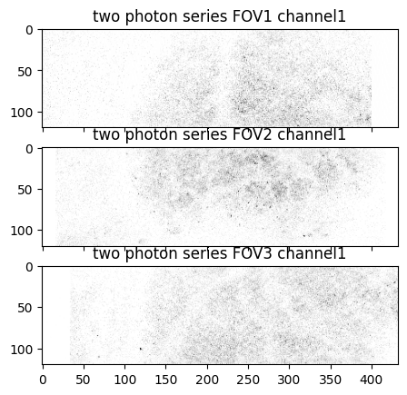

```python
# Visualize the imaging data.
from matplotlib import pyplot as plt
fig, axs = plt.subplots(nrows=len(photon_series_names), ncols=1, sharex=True, sharey=True)
for ps_index,ps_name in enumerate(photon_series_names):
    photon_series = nwbfile.acquisition[ps_name]
    axs[ps_index].imshow(photon_series.data[70], cmap="binary")
    axs[ps_index].set_title(ps_name.replace("_"," "))
plt.show()
```

Imaging metadata include information on the **device** used to acquire the image and the **optical channel** specs contained in the imaging plane object

```python
nwbfile.devices["two_photon_microscope"]
```

two_photon_microscope (Device)

description: Janelia 2P-RAM mesoscope.

manufacturer: ThorLabs

```python
nwbfile.imaging_planes["imaging_plane_channel1"]
```

imaging_plane_channel1 (ImagingPlane)

**optical_channel**

**0 (OpticalChannel)**

description: Green emitted light was collected through a 525/50 filter and a gallium arsenide phosphide photomultiplier tube (Hamamatsu).

emission_lambda: 525.0

description: Imaging plane for the Green channel recorded with 2p microscope.

**device (Device)**

description: Janelia 2P-RAM mesoscope.

manufacturer: ThorLabs

excitation_lambda: 920.0

indicator: GCaMP6f

location: OB

conversion: 1.0

unit: meters

origin_coords_unit: meters

grid_spacing_unit: meters

## Accessing the segmentation data

The segmentation output for the Two Photon Imaging data is stored in `nwbfile.processing["ophys"]`.

In NWB, the PlaneSegmentation class stores the detected regions of interest in the TwoPhotonSeries data. The ImageSegmentation can contain multiple `PlaneSegmentation` tables, so that we can store results of different segmentation algorithms or different segmentation classes.

We can access the plane segmentation for the TwoPhotonSeries data as `nwbfile.processing["ophys"]["ImageSegmentation"]["PlaneSegmentationChannel_number_Plane_number_"]`.

```python
nwbfile.processing["ophys"]
```

ophys (ProcessingModule)

description: ophys data processing

**average_images (Images)**

description: Average image of from SummaryImages.Average table.

**average_image_FOV1_channel1 (GrayscaleImage)**

description: Average image of FOV1 Channel 1.

**average_image_FOV2_channel1 (GrayscaleImage)**

description: Average image of FOV2 Channel 1.

**average_image_FOV3_channel1 (GrayscaleImage)**

description: Average image of FOV3 Channel 1.

**correlation_images (Images)**

description: Correlation image from SummaryImages.Correlation table.

**correlation_image_FOV1_channel1 (GrayscaleImage)**

description: Correlation image of FOV1 Channel 1

**correlation_image_FOV2_channel1 (GrayscaleImage)**

description: Correlation image of FOV2 Channel 1

**correlation_image_FOV3_channel1 (GrayscaleImage)**

description: Correlation image of FOV3 Channel 1

**fluorescence (Fluorescence)**

**fluorescence_FOV1_channel1 (RoiResponseSeries)**

resolution: -1.0

comments: no comments

description: Fluorescence traces from FOV1 Channel1

conversion: 1.0

offset: 0.0

unit: n.a.

**data**

HDF5 dataset

| Data type | float32 |
| --- | --- |
| Shape | (182000, 17) |
| Array size | 11.80 MiB |
| Chunk shape | (160575, 15) |
| Compression | gzip |
| Compression opts | 4 |
| Uncompressed size (bytes) | 12376000 |
| Compressed size (bytes) | 10756953 |
| Compression ratio | 1.15051167370537 |

**timestamps**

HDF5 dataset

| Data type | float64 |
| --- | --- |
| Shape | (182000,) |
| Array size | 1.39 MiB |
| Chunk shape | (182000,) |
| Compression | gzip |
| Compression opts | 4 |
| Uncompressed size (bytes) | 1456000 |
| Compressed size (bytes) | 1101454 |
| Compression ratio | 1.3218890666337404 |

timestamps_unit: seconds

interval: 1

**rois (DynamicTableRegion)**

description: all ROIs

**table (PlaneSegmentation)**

description: Output from segmenting FOV1 Channel 1.

**imaging_plane (ImagingPlane)**

**optical_channel**

**0 (OpticalChannel)**

description: Green emitted light was collected through a 525/50 filter and a gallium arsenide phosphide photomultiplier tube (Hamamatsu).

emission_lambda: 525.0

description: Imaging plane for the Green channel recorded with 2p microscope.

**device (Device)**

description: Janelia 2P-RAM mesoscope.

manufacturer: ThorLabs

excitation_lambda: 920.0

indicator: GCaMP6f

location: OB

conversion: 1.0

unit: meters

origin_coords_unit: meters

grid_spacing_unit: meters

**columns**

**pixel_mask**

Pixel masks for each ROI

**table**

| id | pixel_mask |
| --- | --- |
| 0 | [[150, 83, 1.0], [151, 83, 1.0], [152, 83, 1.0], [153, 83, 1.0], [154, 83, 1.0], [155, 83, 1.0], [156, 83, 1.0], [157, 83, 1.0], [158, 83, 1.0], [159, 83, 1.0], [160, 83, 1.0], [161, 83, 1.0], [149, 8… |
| 1 | [[152, 91, 1.0], [153, 91, 1.0], [154, 91, 1.0], [155, 91, 1.0], [156, 91, 1.0], [150, 92, 1.0], [151, 92, 1.0], [152, 92, 1.0], [153, 92, 1.0], [154, 92, 1.0], [155, 92, 1.0], [156, 92, 1.0], [157, 9… |
| 2 | [[145, 100, 1.0], [146, 100, 1.0], [147, 100, 1.0], [143, 101, 1.0], [144, 101, 1.0], [145, 101, 1.0], [146, 101, 1.0], [147, 101, 1.0], [148, 101, 1.0], [149, 101, 1.0], [142, 102, 1.0], [143, 102, 1… |
| 3 | [[138, 90, 1.0], [139, 90, 1.0], [140, 90, 1.0], [137, 91, 1.0], [138, 91, 1.0], [139, 91, 1.0], [140, 91, 1.0], [141, 91, 1.0], [136, 92, 1.0], [137, 92, 1.0], [138, 92, 1.0], [139, 92, 1.0], [140, 9… |

... and 13 more row(s).

**fluorescence_FOV2_channel1 (RoiResponseSeries)**

resolution: -1.0

comments: no comments

description: Fluorescence traces from FOV2 Channel1

conversion: 1.0

offset: 0.0

unit: n.a.

**data**

HDF5 dataset

| Data type | float32 |
| --- | --- |
| Shape | (182000, 48) |
| Array size | 33.33 MiB |
| Chunk shape | (94775, 25) |
| Compression | gzip |
| Compression opts | 4 |
| Uncompressed size (bytes) | 34944000 |
| Compressed size (bytes) | 30484595 |
| Compression ratio | 1.1462838853525854 |

**timestamps**

HDF5 dataset

| Data type | float64 |
| --- | --- |
| Shape | (182000,) |
| Array size | 1.39 MiB |
| Chunk shape | (182000,) |
| Compression | gzip |
| Compression opts | 4 |
| Uncompressed size (bytes) | 1456000 |
| Compressed size (bytes) | 1101454 |
| Compression ratio | 1.3218890666337404 |

timestamps_unit: seconds

interval: 1

**rois (DynamicTableRegion)**

description: all ROIs

**table (PlaneSegmentation)**

description: Output from segmenting FOV2 Channel 1.

**imaging_plane (ImagingPlane)**

**optical_channel**

**0 (OpticalChannel)**

description: Green emitted light was collected through a 525/50 filter and a gallium arsenide phosphide photomultiplier tube (Hamamatsu).

emission_lambda: 525.0

description: Imaging plane for the Green channel recorded with 2p microscope.

**device (Device)**

description: Janelia 2P-RAM mesoscope.

manufacturer: ThorLabs

excitation_lambda: 920.0

indicator: GCaMP6f

location: OB

conversion: 1.0

unit: meters

origin_coords_unit: meters

grid_spacing_unit: meters

**columns**

**pixel_mask**

Pixel masks for each ROI

**table**

| id | pixel_mask |
| --- | --- |
| 0 | [[159, 51, 1.0], [160, 51, 1.0], [154, 52, 1.0], [155, 52, 1.0], [156, 52, 1.0], [157, 52, 1.0], [158, 52, 1.0], [159, 52, 1.0], [160, 52, 1.0], [161, 52, 1.0], [162, 52, 1.0], [151, 53, 1.0], [152, 5… |
| 1 | [[136, 63, 1.0], [137, 63, 1.0], [138, 63, 1.0], [139, 63, 1.0], [140, 63, 1.0], [141, 63, 1.0], [135, 64, 1.0], [136, 64, 1.0], [137, 64, 1.0], [138, 64, 1.0], [139, 64, 1.0], [140, 64, 1.0], [141, 6… |
| 2 | [[144, 96, 1.0], [145, 96, 1.0], [150, 96, 1.0], [151, 96, 1.0], [142, 97, 1.0], [143, 97, 1.0], [144, 97, 1.0], [145, 97, 1.0], [146, 97, 1.0], [147, 97, 1.0], [148, 97, 1.0], [149, 97, 1.0], [150, 9… |
| 3 | [[146, 85, 1.0], [144, 86, 1.0], [145, 86, 1.0], [146, 86, 1.0], [147, 86, 1.0], [148, 86, 1.0], [149, 86, 1.0], [143, 87, 1.0], [144, 87, 1.0], [145, 87, 1.0], [146, 87, 1.0], [147, 87, 1.0], [148, 8… |

... and 44 more row(s).

**fluorescence_FOV3_channel1 (RoiResponseSeries)**

resolution: -1.0

comments: no comments

description: Fluorescence traces from FOV3 Channel1

conversion: 1.0

offset: 0.0

unit: n.a.

**data**

HDF5 dataset

| Data type | float32 |
| --- | --- |
| Shape | (182000, 8) |
| Array size | 5.55 MiB |
| Chunk shape | (182000, 8) |
| Compression | gzip |
| Compression opts | 4 |
| Uncompressed size (bytes) | 5824000 |
| Compressed size (bytes) | 5051373 |
| Compression ratio | 1.1529538602672975 |

**timestamps**

HDF5 dataset

| Data type | float64 |
| --- | --- |
| Shape | (182000,) |
| Array size | 1.39 MiB |
| Chunk shape | (182000,) |
| Compression | gzip |
| Compression opts | 4 |
| Uncompressed size (bytes) | 1456000 |
| Compressed size (bytes) | 1101454 |
| Compression ratio | 1.3218890666337404 |

timestamps_unit: seconds

interval: 1

**rois (DynamicTableRegion)**

description: all ROIs

**table (PlaneSegmentation)**

description: Output from segmenting FOV3 Channel 1.

**imaging_plane (ImagingPlane)**

**optical_channel**

**0 (OpticalChannel)**

description: Green emitted light was collected through a 525/50 filter and a gallium arsenide phosphide photomultiplier tube (Hamamatsu).

emission_lambda: 525.0

description: Imaging plane for the Green channel recorded with 2p microscope.

**device (Device)**

description: Janelia 2P-RAM mesoscope.

manufacturer: ThorLabs

excitation_lambda: 920.0

indicator: GCaMP6f

location: OB

conversion: 1.0

unit: meters

origin_coords_unit: meters

grid_spacing_unit: meters

**columns**

**pixel_mask**

Pixel masks for each ROI

**table**

| id | pixel_mask |
| --- | --- |
| 0 | [[335, 89, 1.0], [332, 90, 1.0], [333, 90, 1.0], [334, 90, 1.0], [335, 90, 1.0], [336, 90, 1.0], [337, 90, 1.0], [338, 90, 1.0], [339, 90, 1.0], [327, 91, 1.0], [328, 91, 1.0], [329, 91, 1.0], [330, 9… |
| 1 | [[325, 77, 1.0], [326, 77, 1.0], [327, 77, 1.0], [328, 77, 1.0], [329, 77, 1.0], [323, 78, 1.0], [324, 78, 1.0], [325, 78, 1.0], [326, 78, 1.0], [327, 78, 1.0], [328, 78, 1.0], [329, 78, 1.0], [330, 7… |
| 2 | [[351, 92, 1.0], [352, 92, 1.0], [353, 92, 1.0], [354, 92, 1.0], [355, 92, 1.0], [349, 93, 1.0], [350, 93, 1.0], [351, 93, 1.0], [352, 93, 1.0], [353, 93, 1.0], [354, 93, 1.0], [355, 93, 1.0], [356, 9… |
| 3 | [[296, 90, 1.0], [297, 90, 1.0], [293, 91, 1.0], [294, 91, 1.0], [295, 91, 1.0], [296, 91, 1.0], [297, 91, 1.0], [298, 91, 1.0], [299, 91, 1.0], [300, 91, 1.0], [291, 92, 1.0], [292, 92, 1.0], [293, 9… |

... and 4 more row(s).

**image_segmentation (ImageSegmentation)**

**plane_segmentation_FOV1_channel1 (PlaneSegmentation)**

description: Output from segmenting FOV1 Channel 1.

**imaging_plane (ImagingPlane)**

**optical_channel**

**0 (OpticalChannel)**

description: Green emitted light was collected through a 525/50 filter and a gallium arsenide phosphide photomultiplier tube (Hamamatsu).

emission_lambda: 525.0

description: Imaging plane for the Green channel recorded with 2p microscope.

**device (Device)**

description: Janelia 2P-RAM mesoscope.

manufacturer: ThorLabs

excitation_lambda: 920.0

indicator: GCaMP6f

location: OB

conversion: 1.0

unit: meters

origin_coords_unit: meters

grid_spacing_unit: meters

**columns**

**pixel_mask**

Pixel masks for each ROI

**table**

| id | pixel_mask |
| --- | --- |
| 0 | [[150, 83, 1.0], [151, 83, 1.0], [152, 83, 1.0], [153, 83, 1.0], [154, 83, 1.0], [155, 83, 1.0], [156, 83, 1.0], [157, 83, 1.0], [158, 83, 1.0], [159, 83, 1.0], [160, 83, 1.0], [161, 83, 1.0], [149, 8… |
| 1 | [[152, 91, 1.0], [153, 91, 1.0], [154, 91, 1.0], [155, 91, 1.0], [156, 91, 1.0], [150, 92, 1.0], [151, 92, 1.0], [152, 92, 1.0], [153, 92, 1.0], [154, 92, 1.0], [155, 92, 1.0], [156, 92, 1.0], [157, 9… |
| 2 | [[145, 100, 1.0], [146, 100, 1.0], [147, 100, 1.0], [143, 101, 1.0], [144, 101, 1.0], [145, 101, 1.0], [146, 101, 1.0], [147, 101, 1.0], [148, 101, 1.0], [149, 101, 1.0], [142, 102, 1.0], [143, 102, 1… |
| 3 | [[138, 90, 1.0], [139, 90, 1.0], [140, 90, 1.0], [137, 91, 1.0], [138, 91, 1.0], [139, 91, 1.0], [140, 91, 1.0], [141, 91, 1.0], [136, 92, 1.0], [137, 92, 1.0], [138, 92, 1.0], [139, 92, 1.0], [140, 9… |

... and 13 more row(s).

**plane_segmentation_FOV2_channel1 (PlaneSegmentation)**

description: Output from segmenting FOV2 Channel 1.

**imaging_plane (ImagingPlane)**

**optical_channel**

**0 (OpticalChannel)**

description: Green emitted light was collected through a 525/50 filter and a gallium arsenide phosphide photomultiplier tube (Hamamatsu).

emission_lambda: 525.0

description: Imaging plane for the Green channel recorded with 2p microscope.

**device (Device)**

description: Janelia 2P-RAM mesoscope.

manufacturer: ThorLabs

excitation_lambda: 920.0

indicator: GCaMP6f

location: OB

conversion: 1.0

unit: meters

origin_coords_unit: meters

grid_spacing_unit: meters

**columns**

**pixel_mask**

Pixel masks for each ROI

**table**

| id | pixel_mask |
| --- | --- |
| 0 | [[159, 51, 1.0], [160, 51, 1.0], [154, 52, 1.0], [155, 52, 1.0], [156, 52, 1.0], [157, 52, 1.0], [158, 52, 1.0], [159, 52, 1.0], [160, 52, 1.0], [161, 52, 1.0], [162, 52, 1.0], [151, 53, 1.0], [152, 5… |
| 1 | [[136, 63, 1.0], [137, 63, 1.0], [138, 63, 1.0], [139, 63, 1.0], [140, 63, 1.0], [141, 63, 1.0], [135, 64, 1.0], [136, 64, 1.0], [137, 64, 1.0], [138, 64, 1.0], [139, 64, 1.0], [140, 64, 1.0], [141, 6… |
| 2 | [[144, 96, 1.0], [145, 96, 1.0], [150, 96, 1.0], [151, 96, 1.0], [142, 97, 1.0], [143, 97, 1.0], [144, 97, 1.0], [145, 97, 1.0], [146, 97, 1.0], [147, 97, 1.0], [148, 97, 1.0], [149, 97, 1.0], [150, 9… |
| 3 | [[146, 85, 1.0], [144, 86, 1.0], [145, 86, 1.0], [146, 86, 1.0], [147, 86, 1.0], [148, 86, 1.0], [149, 86, 1.0], [143, 87, 1.0], [144, 87, 1.0], [145, 87, 1.0], [146, 87, 1.0], [147, 87, 1.0], [148, 8… |

... and 44 more row(s).

**plane_segmentation_FOV3_channel1 (PlaneSegmentation)**

description: Output from segmenting FOV3 Channel 1.

**imaging_plane (ImagingPlane)**

**optical_channel**

**0 (OpticalChannel)**

description: Green emitted light was collected through a 525/50 filter and a gallium arsenide phosphide photomultiplier tube (Hamamatsu).

emission_lambda: 525.0

description: Imaging plane for the Green channel recorded with 2p microscope.

**device (Device)**

description: Janelia 2P-RAM mesoscope.

manufacturer: ThorLabs

excitation_lambda: 920.0

indicator: GCaMP6f

location: OB

conversion: 1.0

unit: meters

origin_coords_unit: meters

grid_spacing_unit: meters

**columns**

**pixel_mask**

Pixel masks for each ROI

**table**

| id | pixel_mask |
| --- | --- |
| 0 | [[335, 89, 1.0], [332, 90, 1.0], [333, 90, 1.0], [334, 90, 1.0], [335, 90, 1.0], [336, 90, 1.0], [337, 90, 1.0], [338, 90, 1.0], [339, 90, 1.0], [327, 91, 1.0], [328, 91, 1.0], [329, 91, 1.0], [330, 9… |
| 1 | [[325, 77, 1.0], [326, 77, 1.0], [327, 77, 1.0], [328, 77, 1.0], [329, 77, 1.0], [323, 78, 1.0], [324, 78, 1.0], [325, 78, 1.0], [326, 78, 1.0], [327, 78, 1.0], [328, 78, 1.0], [329, 78, 1.0], [330, 7… |
| 2 | [[351, 92, 1.0], [352, 92, 1.0], [353, 92, 1.0], [354, 92, 1.0], [355, 92, 1.0], [349, 93, 1.0], [350, 93, 1.0], [351, 93, 1.0], [352, 93, 1.0], [353, 93, 1.0], [354, 93, 1.0], [355, 93, 1.0], [356, 9… |
| 3 | [[296, 90, 1.0], [297, 90, 1.0], [293, 91, 1.0], [294, 91, 1.0], [295, 91, 1.0], [296, 91, 1.0], [297, 91, 1.0], [298, 91, 1.0], [299, 91, 1.0], [300, 91, 1.0], [291, 92, 1.0], [292, 92, 1.0], [293, 9… |

... and 4 more row(s).

#### Plot Correlation Images

```python
correlation_images_names = list(nwbfile.processing["ophys"]["correlation_images"].images.keys())
_ = [print(name) for name in correlation_images_names]
```

```
correlation_image_FOV1_channel1
correlation_image_FOV2_channel1
correlation_image_FOV3_channel1
```

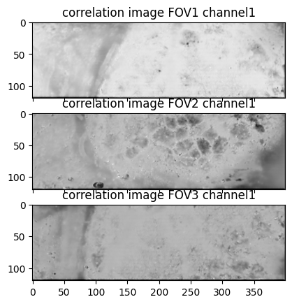

```python
fig, axs = plt.subplots(nrows=len(correlation_images_names), ncols=1, sharex=True, sharey=True)
for ci_index,ci_name in enumerate(correlation_images_names):
    correlation_image = nwbfile.processing["ophys"]["correlation_images"].images[ci_name]
    axs[ci_index].imshow(correlation_image.data[:].T, cmap="binary")
    axs[ci_index].set_title(ci_name.replace("_"," "))
plt.show()
```

#### Plot Average Images

```python
average_images_names = list(nwbfile.processing["ophys"]["average_images"].images.keys())
_ = [print(name) for name in average_images_names]
```

```
average_image_FOV1_channel1
average_image_FOV2_channel1
average_image_FOV3_channel1
```

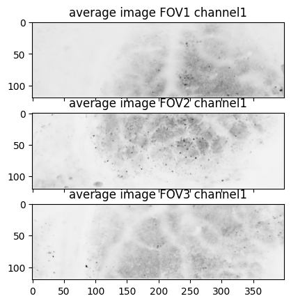

```python
fig, axs = plt.subplots(nrows=len(average_images_names), ncols=1, sharex=True, sharey=True)
for ai_index,ai_name in enumerate(average_images_names):
    average_image = nwbfile.processing["ophys"]["average_images"].images[ai_name]
    axs[ai_index].imshow(average_image.data[:].T, cmap="binary")
    axs[ai_index].set_title(ai_name.replace("_"," "))
plt.show()
```

#### Plot Image Segmentation

```python
plane_segmentation_names = list(nwbfile.processing["ophys"]["image_segmentation"].plane_segmentations.keys())
_ = [print(name) for name in nwbfile.processing["ophys"]["image_segmentation"].plane_segmentations.keys()]
```

```
plane_segmentation_FOV1_channel1
plane_segmentation_FOV2_channel1
plane_segmentation_FOV3_channel1
```

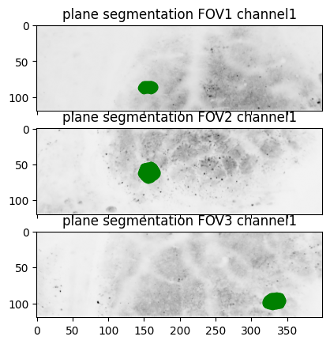

```python
ROI_index = 0

fig, axs = plt.subplots(nrows=len(plane_segmentation_names), ncols=1, sharex=True, sharey=True)
for ps_index,ps_name in enumerate(plane_segmentation_names):
    average_image = nwbfile.processing["ophys"]["average_images"].images[average_images_names[ps_index]]
    axs[ps_index].imshow(average_image.data[:].T, cmap="binary")
    plane_segmentation = nwbfile.processing["ophys"]["image_segmentation"].plane_segmentations[ps_name]
    x_coordinates = [pix[0] for pix in plane_segmentation[ROI_index].pixel_mask[0]]
    y_coordinates = [pix[1] for pix in plane_segmentation[ROI_index].pixel_mask[0]]
    axs[ps_index].scatter(x_coordinates, y_coordinates, color="green")
    axs[ps_index].set_title(ps_name.replace("_"," "))
plt.show()
```

## Visualize fluorescence traces

The fluroscence traces are stored in a Fluorescence container, the raw traces can be accessed as `nwbfile.processing["ophys"]["Fluorescence"]["RoiResponseSeries"]`.

```python
import pandas as pd
import warnings
warnings.simplefilter(action='ignore', category=pd.errors.PerformanceWarning)

fluorescence_traces_names = [name for name in nwbfile.processing["ophys"]["fluorescence"].roi_response_series.keys()]

fluorescence_traces_name = fluorescence_traces_names[0]
fluorescence_traces = nwbfile.processing["ophys"]["fluorescence"][fluorescence_traces_name].data[:1000, :10]
df = pd.DataFrame(fluorescence_traces)
df["time"] = nwbfile.processing["ophys"]["fluorescence"][fluorescence_traces_name].timestamps[:1000]
df.set_index("time", inplace=True)
df.columns.name = 'ROIs'

import plotly.express as px

fig = px.line(df, facet_row="ROIs", facet_row_spacing=0.01)

# hide and lock down axes
fig.update_xaxes(visible=True, fixedrange=False)
fig.update_yaxes(visible=False, fixedrange=False)

# remove facet/subplot labels
fig.update_layout(annotations=[], overwrite=True)

# strip down the rest of the plot
fig.update_layout(
    showlegend=True,
    plot_bgcolor="white",
    margin=dict(t=10, l=10, b=10, r=10)
)

fig.show(config=dict(displayModeBar=True))
```

[interactive chart not shown]

# Access Odor stimuli

This section demonstrates how to access the odor stimulation data and metadata.

```python
nwbfile.trials.to_dataframe()
```

| id | start_time | stop_time | odorant | concentration | solution_date |
| --- | --- | --- | --- | --- | --- |
| 0 | 59.2888 | 60.2928 | Methyl Salicylate | 0.1 | 2022-05-17 |
| 1 | 60.2966 | 61.2995 | Methyl Salicylate | 0.1 | 2022-05-17 |
| 2 | 61.3034 | 62.3067 | Methyl Salicylate | 0.1 | 2022-05-17 |
| 3 | 62.3106 | 63.3130 | Methyl Salicylate | 0.1 | 2022-05-17 |
| 4 | 63.3170 | 64.3213 | Methyl Salicylate | 0.1 | 2022-05-17 |
| ... | ... | ... | ... | ... | ... |
| 495 | 9675.0000 | 9676.0000 | Methyl Salicylate | 0.1 | 2022-05-17 |
| 496 | 9676.0000 | 9677.0100 | Methyl Salicylate | 0.1 | 2022-05-17 |
| 497 | 9677.0100 | 9678.0100 | Methyl Salicylate | 0.1 | 2022-05-17 |
| 498 | 9678.0200 | 9679.0200 | Methyl Salicylate | 0.1 | 2022-05-17 |
| 499 | 9679.0200 | 9680.0300 | Methyl Salicylate | 0.1 | 2022-05-17 |

500 rows × 5 columns

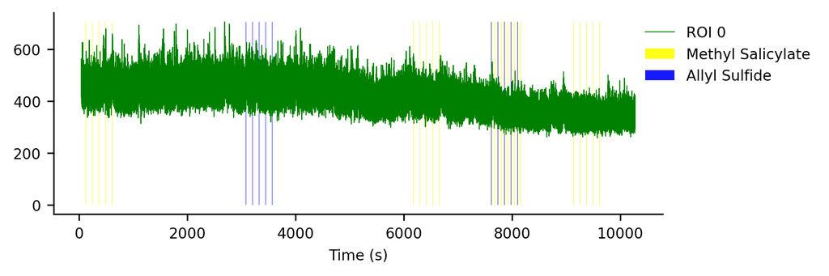

```python
# Prepare data for plotting
import numpy as np
ROI_index=0
start=0
stop=-1
fluorescence_data = nwbfile.processing["ophys"]["fluorescence"][fluorescence_traces_name].data[start:stop, ROI_index]
fluorescence_timestamps = nwbfile.processing["ophys"]["fluorescence"][fluorescence_traces_name].timestamps[start:stop]

fig, ax = plt.subplots(figsize=(6, 2), dpi=300)
line_handle, = ax.plot(fluorescence_timestamps, fluorescence_data, color="green", linewidth=0.5, label="ROI {ROI_index}".format(ROI_index=ROI_index))

stimulus_table = nwbfile.trials.to_dataframe()
methyl_salicylate_stim = "Methyl Salicylate"
methyl_salicylate_stim_table = stimulus_table[stimulus_table["odorant"]==methyl_salicylate_stim]
methyl_salicylate_stim_handles = []
for (stimulus_start, stimulus_stop) in zip(methyl_salicylate_stim_table["start_time"], methyl_salicylate_stim_table["stop_time"]):
    methyl_salicylate_stim_handle = ax.fill_between(fluorescence_timestamps, np.nanmax(fluorescence_data), where=(fluorescence_timestamps >= stimulus_start) & (fluorescence_timestamps <= stimulus_stop),
                                    color='yellow', edgecolor='none', alpha=0.9, label=methyl_salicylate_stim)
    methyl_salicylate_stim_handles.append(methyl_salicylate_stim_handle)

allyl_sulfide_stim = "Allyl Sulfide"
allyl_sulfide_stim_table = stimulus_table[stimulus_table["odorant"]==allyl_sulfide_stim]
allyl_sulfide_stim_handles = []
for (stimulus_start, stimulus_stop) in zip(allyl_sulfide_stim_table["start_time"], allyl_sulfide_stim_table["stop_time"]):
    allyl_sulfide_stim_handle = ax.fill_between(fluorescence_timestamps, np.nanmax(fluorescence_data), where=(fluorescence_timestamps >= stimulus_start) & (fluorescence_timestamps <= stimulus_stop),
                                    color='blue', edgecolor='none', alpha=0.9, label=allyl_sulfide_stim)
    allyl_sulfide_stim_handles.append(allyl_sulfide_stim_handle)

# Hide top and right spines
ax.spines['top'].set_visible(False)
ax.spines['right'].set_visible(False)

# Create the legend with the appropriate handles
handles = [line_handle, methyl_salicylate_stim_handles[0], allyl_sulfide_stim_handles[0]]
labels = ["ROI {ROI_index}".format(ROI_index=ROI_index), methyl_salicylate_stim, allyl_sulfide_stim]
ax.legend(handles, labels, frameon=False, bbox_to_anchor=(.95, 1), loc='upper left', prop={'size': 8})

ax.tick_params(axis='y', labelsize=8)
plt.xlabel('Time (s)', fontsize=8)
plt.tick_params(axis='x', labelsize=8)
plt.show()
```

# Access Treadmill Traces

This section demonstrates how to access the treadmill data.

```python
nwbfile.acquisition["treadmill_position"]
```

treadmill_position (SpatialSeries)

resolution: -1.0

comments: no comments

description: treadmill position from Treadmill table

conversion: 1.0

offset: 0.0

unit: meters

**data**

HDF5 dataset

| Data type | float64 |
| --- | --- |
| Shape | (1044900,) |
| Array size | 7.97 MiB |
| Chunk shape | (1044900,) |
| Compression | gzip |
| Compression opts | 4 |
| Uncompressed size (bytes) | 8359200 |
| Compressed size (bytes) | 449850 |
| Compression ratio | 18.58219406468823 |

**timestamps**

HDF5 dataset

| Data type | float64 |
| --- | --- |
| Shape | (1044900,) |
| Array size | 7.97 MiB |
| Chunk shape | (1044900,) |
| Compression | gzip |
| Compression opts | 4 |
| Uncompressed size (bytes) | 8359200 |
| Compressed size (bytes) | 6151141 |
| Compression ratio | 1.3589673850753867 |

timestamps_unit: seconds

interval: 1

reference_frame: unknown

**timestamp_link**

0: processing/behavior/treadmill_velocity/timestamps

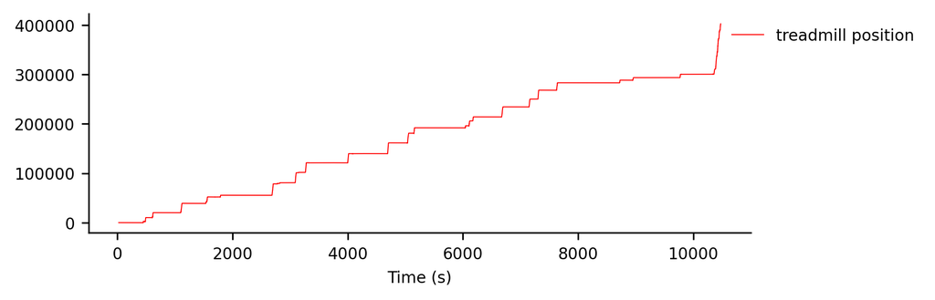

```python
start=0
stop=-1
treadmill_data = nwbfile.acquisition["treadmill_position"].data[start:stop]
treadmill_timestamps = nwbfile.acquisition["treadmill_position"].timestamps[start:stop]

fig, ax = plt.subplots(figsize=(6, 2), dpi=300)
ax.plot(treadmill_timestamps, treadmill_data, color="red", linewidth=0.5, label="treadmill position")

# Hide top and right spines
ax.spines['top'].set_visible(False)
ax.spines['right'].set_visible(False)

# Create the
ax.legend(frameon=False, bbox_to_anchor=(.95, 1), loc='upper left', prop={'size': 8})

ax.tick_params(axis='y', labelsize=8)
plt.xlabel('Time (s)', fontsize=8)
plt.tick_params(axis='x', labelsize=8)
plt.show()
```

```python
nwbfile.processing["behavior"]["treadmill_velocity"]
```

treadmill_velocity (TimeSeries)

resolution: -1.0

comments: no comments

description: treadmill velocity from Treadmill table

conversion: 1.0

offset: 0.0

unit: unknown

**data**

HDF5 dataset

| Data type | float64 |
| --- | --- |
| Shape | (1044900,) |
| Array size | 7.97 MiB |
| Chunk shape | (1044900,) |
| Compression | gzip |
| Compression opts | 4 |
| Uncompressed size (bytes) | 8359200 |
| Compressed size (bytes) | 7209847 |
| Compression ratio | 1.1594143398604715 |

**timestamps (link to acquisition/treadmill_position/timestamps)**

HDF5 dataset

| Data type | float64 |
| --- | --- |
| Shape | (1044900,) |
| Array size | 7.97 MiB |
| Chunk shape | (1044900,) |
| Compression | gzip |
| Compression opts | 4 |
| Uncompressed size (bytes) | 8359200 |
| Compressed size (bytes) | 6151141 |
| Compression ratio | 1.3589673850753867 |

timestamps_unit: seconds

interval: 1

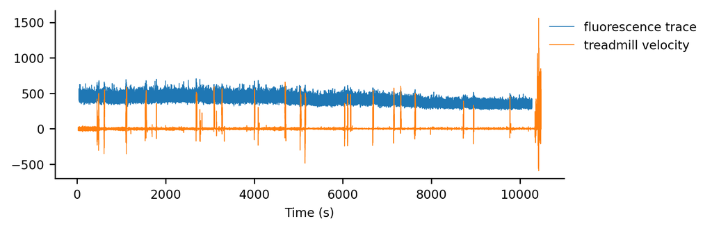

```python
data = nwbfile.processing["behavior"]["treadmill_velocity"].data[start:stop]
treadmill_timestamps = nwbfile.acquisition["treadmill_position"].timestamps[start:stop]

fig, ax = plt.subplots(figsize=(6, 2), dpi=300)
ax.plot(fluorescence_timestamps, fluorescence_data, linewidth=0.5, label="fluorescence trace")
ax.plot(treadmill_timestamps, data*25, linewidth=0.5, label="treadmill velocity")

# Hide top and right spines
ax.spines['top'].set_visible(False)
ax.spines['right'].set_visible(False)

# Create the
ax.legend(frameon=False, bbox_to_anchor=(.95, 1), loc='upper left', prop={'size': 8})

ax.tick_params(axis='y', labelsize=8)
plt.xlabel('Time (s)', fontsize=8)
plt.tick_params(axis='x', labelsize=8)
plt.show()
```